# Lab 3 - Statistical Description of Uncertainty

```python
# (a) Calculate the standard deviation.

mean_10 = np.mean(data10)
std_10 = np.sqrt(sum([(x - mean_10)**2 for x in data10]) / float(len(data10)))
print ("Standard deviation of the 10 datapoints is", std_10)

mean_100 = np.mean(data100)
std_100 = np.sqrt(sum([(x - mean_100)**2 for x in data100]) / float(len(data100)))
print ("Standard deviation of the 100 datapoints is", std_100)

mean_1000 = np.mean(data1000)
std_1000 = np.sqrt(sum([(x - mean_1000)**2 for x in data1000]) / float(len(data1000)))
print ("Standard deviation of the 1000 datapoints is", std_1000)

mean_10000 = np.mean(data10000)
std_10000 = np.sqrt(sum([(x - mean_10000)**2 for x in data10000]) / float(len(data10000)))
print ("Standard deviation of the 10000 datapoints is", std_10000)
```

```
Standard deviation of the 10 datapoints is 0.45651834574308187
Standard deviation of the 100 datapoints is 0.4641405390611771
Standard deviation of the 1000 datapoints is 0.5021895482783371
Standard deviation of the 10000 datapoints is 0.5014906203699085
```

```python
# (b) Calculate the standard deviation of the mean.
std_mean_10 = std_10 / np.sqrt(10)
print ("Standard deviation of mean for the 10 datapoints is", std_mean_10)

std_mean_100 = std_100 / np.sqrt(100)
print ("Standard deviation of mean for the 100 datapoints is", std_mean_100)

std_mean_1000 = std_1000 / np.sqrt(1000)
print ("Standard deviation of mean for the 1000 datapoints is", std_mean_1000)

std_mean_10000 = std_10000 / np.sqrt(10000)
print ("Standard deviation of mean for the 10000 datapoints is", std_mean_10000)
```

```
Standard deviation of mean for the 10 datapoints is 0.14436377662003722
Standard deviation of mean for the 100 datapoints is 0.046414053906117705
Standard deviation of mean for the 1000 datapoints is 0.015880627896906353
Standard deviation of mean for the 10000 datapoints is 0.005014906203699086
```

##### (c) Finally, jot down a sentence or two about the difference between the standard deviation and the standard deviation of the mean.

The standard deviation describes the uncertainty of each data point, where the standard deviation of mean describes the uncertainty of the average accross all data points.

## P3.4

##### Take a second to jot down a paragraph about the difference between random and systematic error.

Random errors are errors that come from the nature of measuring. For example, when measuring the weight of various elements, there will always be error. Some error is negative (measuring an element to be to light) and some error is positive (measuring an element to be too heavy). Conjecturally, these will be evenly distributed (about the same number of negative errors as positive). Systematic error involves a consistent error unnaturally found while measuring. For example, the scale being used to measure may be off by 2g from reality. Clearly, systematic errors cannot be caluculated, only observed and compensated for.

## P3.5

**Manually assign each of the 10 data points from our length-of-rod measurements to the bins in the figure. Draw the histogramon in your lab notebook.**

[figure not shown]

## P3.6

Using the `hist` function inside of `matplotlib.pyplot`, create 4 histograms, one for each data set provided on iLearn.

```python
import matplotlib.pyplot as plt
```

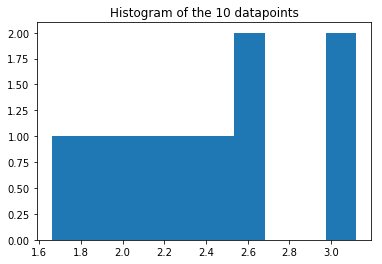

```python
plt.title("Histogram of the 10 datapoints")
x = plt.hist(data10)
```

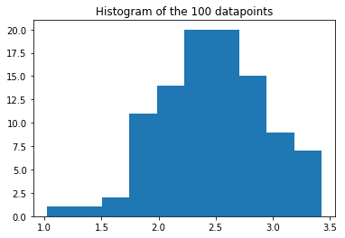

```python
plt.title("Histogram of the 100 datapoints")
x = plt.hist(data100)
```

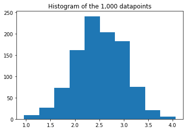

```python
plt.title("Histogram of the 1,000 datapoints")
x = plt.hist(data1000)
```

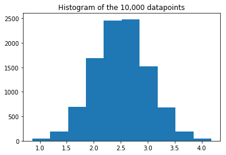

```python
plt.title("Histogram of the 10,000 datapoints")
x = plt.hist(data10000)
```

## P3.7

Each person in class should shoot the steel ball vertically out of the cannon and measure the distance from the exit point to the max height. Repeat the experiment 5 times, recording each measurement. Set the launch strength to the second click. On the board at the front of the room, write down your 5 values for the vertical distance traveled by the steel ball. If there are 20 students in class, this should generate 100 data points.

*Here are our height measurements from launching the cannon:*

| Trial | Height (cm) |
| --- | --- |
| 1 | 149 |
| 2 | 153 |
| 3 | 153 |
| 4 | 154 |
| 5 | 153 |

We are using this formula to evaluate the initial velocity: $$ v = \sqrt{2 g \Delta x} $$

##### (a) Use Python to calculate a list of launch speeds by evaluating equation for each data point on the board. This should generate a list of launch speeds.

```python
heights = [131.5, 135.5, 134.5, 137.5, 143.5, 145.5, 146.5, 148.5, 147.5, 146.5, 153.6, 153.7, 153.6, 155.6, 154.6, 153.8, 151.6, 150.1, 149.1, 152.1, 160, 154, 151, 155, 158, 147, 148, 150, 154, 154, 151, 153, 154, 152, 153, 149, 153, 149, 153, 153, 154, 153, 149, 149.5, 149.5, 149, 150, 151, 150, 152, 153, 151, 149, 152, 151, 151, 151, 147, 151, 153, 155, 156, 153, 154, 154, 153, 154, 151.7, 152.7, 152.7, 152.7, 153.7, 153.2, 151.5, 152, 153.3, 152.7, 150, 147, 149, 151, 149, 148.5, 151.5, 151.5, 152.5, 151.5, 153, 154] # in cm
g = 980 # cm/s^2

velocities = [np.sqrt(2*g*x) for x in heights]
print ("Velocties in cm/s: ", velocities)
```

[output not shown]

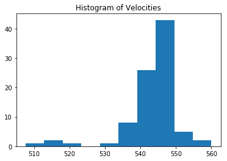

```python
# (b) Use Python to generate a histogram of the speeds.
plt.title("Histogram of Velocities")
x = plt.hist(velocities)
```

```python
# (c) Use Python to calculate the mean and standard deviation of the speeds.
print ("Velocity mean:", np.mean(velocities))
print ("Velocity standard deviation:", np.std(velocities))
```

```
Velocity mean: 543.6884997620178
Velocity standard deviation: 8.093939445031966
```

**(d) In your lab notebook, comment on the value for the launch speed that you would feel most comfortable using and one that you would not feel comfortable using.**

I would feel most comfortable using $545_{\frac{cm}{s}}$ because it was most observed. I would feel least comfortable using $510_{\frac{cm}{s}}$ because it was least observed and furthest away from the average.

# Take home thoughts

Uncertainty is much easier to understand in statistics I feel. There is a lot of power in understanding error through verified mathematical methods. The mean helps us reduce the data set into a single value, and the standard deviation gives us an idea about how much the data varries. I used them a lot in my machine learning class.

# Sign off

- Kyle West
- Brandon Welch